# Zadanie 1

## Zadanie 1

Na początku pobieramy dane i wstępnie je przetwarzamy: nazywamy kolumny oraz wybieramy interesujące nas stacje pomiarowe oraz kolumny. Wybraliśmy Pszczynę, Pułtusk oraz Białowieżę.

```r
df <- read.csv('data/k_d_07_2021.csv', header = FALSE)
col_names <- c('station_code', 'station_name', 'year', 'month', 'day',
               'T_MAX', 'status_T_MAX', 'T_MIN', 'status_T_MIN', 'T_AVG', 'status_T_AVG',
               'T_MIN_GROUND', 'status_T_MIN_GROUND', 'SUM_OF_PRECIPITATION', 'status_SUM_OF_PRECIPITATION',
               'TYPE_OF_RAINFALL', 'SNOW_COVER_HEIGHT', 'status_SNOW_COVER_HEIGHT')
colnames(df) <- col_names

our_stations = c('PSZCZYNA', 'PUŁTUSK', 'BIAŁOWIEŻA')
df <- df[df$station_name %in% our_stations, ]

useful_columns <- c('station_name', 'year', 'month', 'day', 'T_MAX', 'T_MIN', 'T_AVG')
df <- df[, useful_columns]
```

### zad1 a1

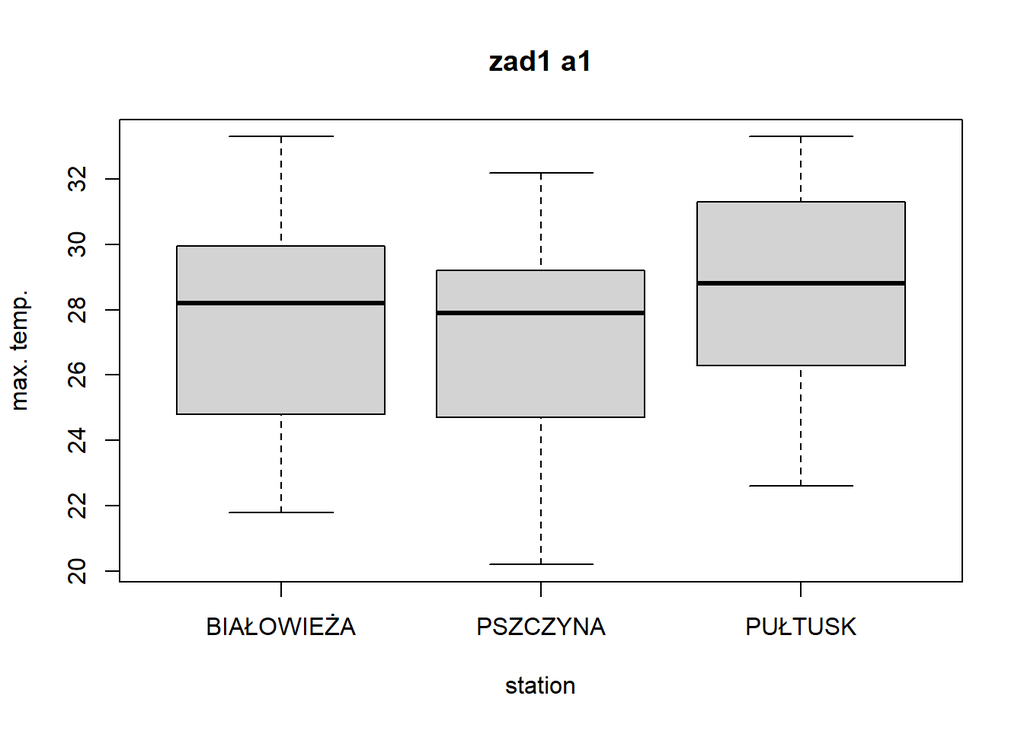

```r
boxplot(T_MAX ~ station_name, df, xlab="station", ylab="max. temp.", main="zad1 a1")
```

Uśredniając - najwyższe temperatury w ciągu dnia zostały zanotowane w Pułtusku. Różnice są jednak minimalne: - średnia w obrębie jednego stopnia Celsujsza, - kwartyle w znacznej mierze nachodzą na siebie. Z inżynierskim przybliżeniem możemy stwierdzić, że lipiec 2021 roku był tak samo ciepły w tych rejonach Polski.

### zad1 a2

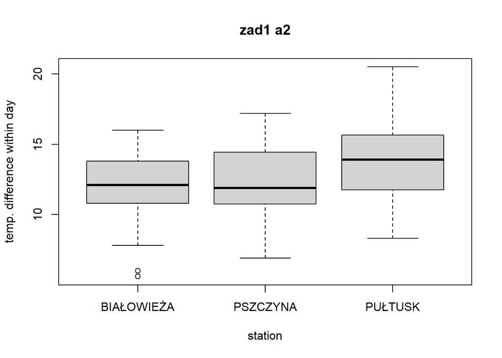

```r
df$DAILY_T_DIFF <- df$T_MAX - df$T_MIN
boxplot(
  DAILY_T_DIFF ~ station_name, df, xlab="station",
  ylab="temp. difference within day", main="zad1 a2"
)
```

### zad 1a3

W celu wykonania tego podpunktu musieliśmy zdefiniować pomocnicze funkcje:

```r
if (!require(dplyr))
  install.packages('dplyr')
library(dplyr) # for mutate()

count_diff_between_days <- function(df){
  # make sure its sorted in ascending way
  sorted <- df[order(df$DATE), ]

  # calculate difference between this and previous day
  result <- mutate(sorted, DIFF_MAX_T_BETWEEN_PREVIOUS_DAY = T_MAX - lag(T_MAX))
  return(result)
}


count_diff_between_days_for_each_station <- function(df){
  station_dfs <- split(df, with(df, interaction(station_name)), drop = TRUE)
  result = data.frame()
  for(station_df in station_dfs){
    station_result <- count_diff_between_days(station_df)
    result <- rbind(result, station_result)
  }
  return (result)
}
```

Za ich pomocą jesteśmy w stanie w łatwy sposób przetworzyć dane i je zobrazować:

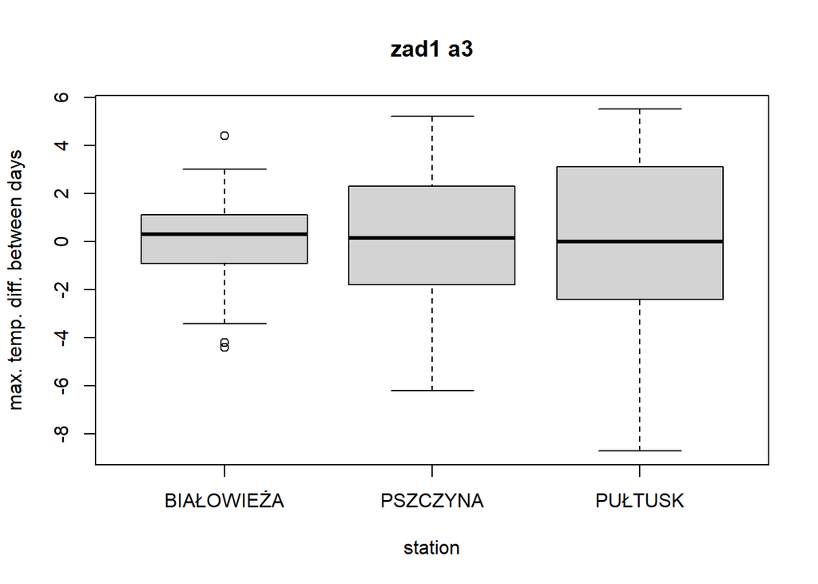

```r
df$DATE <- as.Date(paste(df$year, df$month, df$day, sep = "-"), "%Y-%m-%d")
df <- subset(df, select = -c(year, month, day))
df <- count_diff_between_days_for_each_station(df)

boxplot(
  DIFF_MAX_T_BETWEEN_PREVIOUS_DAY ~ station_name, df, xlab="station",
  ylab="max. temp. diff. between days", main="zad1 a3"
)
```

Uśredniając, we wszystkich analizowanych stacjach wahania temperatury z dnia na dzień oscylują w okolicy zera. Jednak, możemy zauważyć, że wariancja była najmniejsza w Białowieży, a największa w Pułtusku.

### zad1 b1

Wybraliśmy stację Pułtusk.

Szacowanie parametrów rozkładu normalnego:

```r
b1_data <- df[df$station_name == 'PUŁTUSK', ]
b1_data <-b1_data$DIFF_MAX_T_BETWEEN_PREVIOUS_DAY
b1_mean <- mean(b1_data, na.rm = TRUE)
b1_sd <- sd(b1_data, na.rm = TRUE)
```

Za ich pomocą możemy narysować:

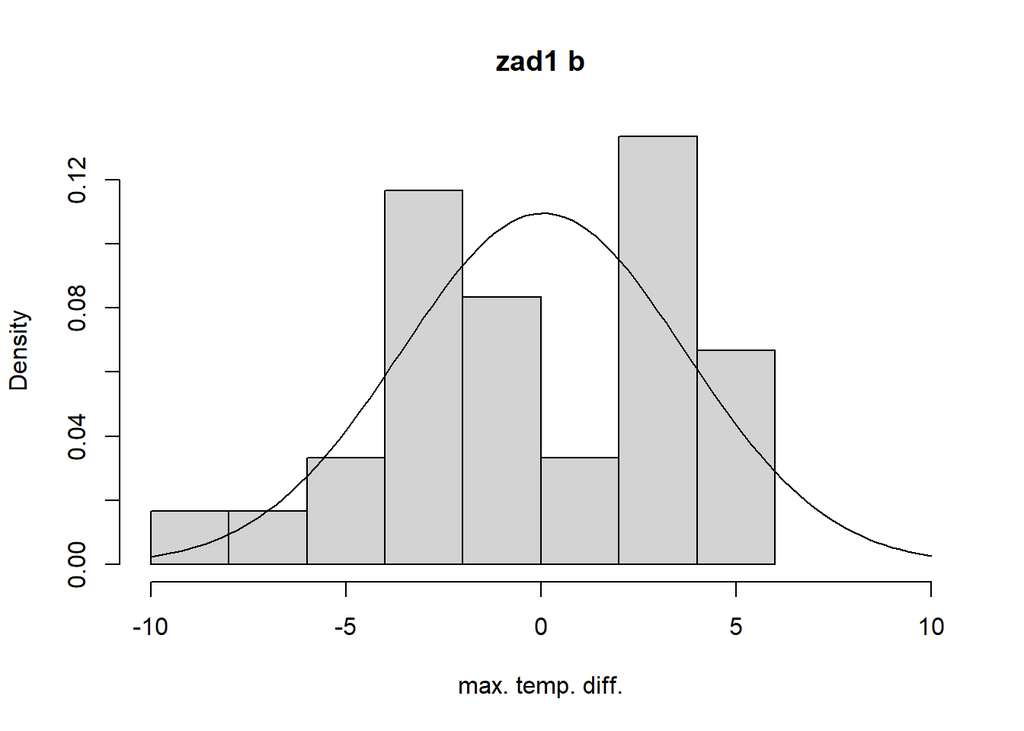

```r
hist(b1_data, prob=TRUE, xlab="max. temp. diff.", main="zad1 b", xlim=c(-10,10))
curve(dnorm(x, mean=b1_mean, sd=b1_sd), add=TRUE, yaxt="n")
```